# Check the descripancy on systematic uncertainty between fig 3 and 5

## Version

- [V20190602](https://xcheung.github.io/sandbox/d20190602.html)
  - Compare uncertainty propagation from Fig 5 to Fig 3in a give $p_{\rm T}$ bin
- [V20190522](https://xcheung.github.io/sandbox/d20190522.html)
  - Newest inputs from Zuman
  - The check presented here is based on this version
- [V20190520](https://xcheung.github.io/sandbox/d20190520.html)
  - Not fully consistent
  - See executive summary there
- [V20190519](https://xcheung.github.io/sandbox/d20190519.html)
  - Corresponding to data files uploaded to the [papge review page](https://alice-publications.web.cern.ch/node/4120)
  - See definition of tables also there

## Uncertainty propagation

The variations of different uncertainty sources as a function of $p_{\rm T}$ in 2.5 < $y$ < 4 are shown in figure 40 in the [analysis note](https://alice-notes.web.cern.ch/node/671). The trend should be similar in each sub-rapidity bin.

Since I do not have all ingredients, two sources are chosen to test the uncertainty propagation:

- **Systematic uncertainty on background subtraction**
- **Systematic uncertainty on detector response**

With the strategy described by Zuman, the value of systematic uncertainty on background subtraction in the total rapidity bin should be the algebra (linear) sum of that in sub-rapidities. Since it is dominant at low-$p_{\rm T}$, the relation should be well kept in this region.

For the uncertainty on detector response, its relative value is correlated with both $p_{\rm T}$ and rapidity in each muon trigger sample. It means, similar as uncertainty on background subtraction, that the value of this uncertainty in total rapidity bin is given by the algebra sum of that in sub-rapidities.

```python
import numpy as np
import matplotlib.pyplot as plt
import matplotlib.gridspec as gridspec

from math import sqrt
from utils import tools, get_data
```

```python
lbin = [ 2.0, 2.5, 3.0, 3.5, 4.0, 4.5, 5.0, 5.5, 6., 7., 8., 10., 20. ]

df3 = get_data('Fig3', lrb=lbin)

ls5 = list(map(chr, range(97, 102)))
ld5 = [ get_data('Fig5%s' % s, lrb=lbin) for s in ls5 ]
df5 = tools.add_data(ld5, lsx=['low','high'], lsq=['stat','sysq'])
```

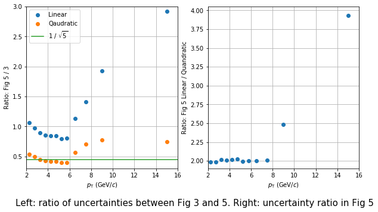

```python
ar = np.array(df3['sysq'])
aq = np.array(df5['sysq'])
al = np.array(df5['sysl'])
ax = np.array(0.5 * (df3['low']+df3['high']))
###############################################################################

dr = 1. / sqrt(5.)
lx, ly = [2., 16], [dr, dr]
###############################################################################

gs  = gridspec.GridSpec(1, 2)
fig = plt.figure(figsize=(10,5))

pad = fig.add_subplot(gs[0,0])
pad.grid(True)
pad.set_xlim(lx)
pad.set_ylim([0.3, 3.0])
pad.set_xlabel(r'$p_{\rm T}$ (GeV/$c$)')
pad.set_ylabel(r'Ratio: Fig 5 / 3')
pad.plot(ax, al / ar, 'o', label='Linear')
pad.plot(ax, aq / ar, 'o', label='Qaudratic')
pad.plot(lx, ly, label=r'1 / $\sqrt{5}$')
pad.legend(loc='best')

pad = fig.add_subplot(gs[0,1])
pad.grid(True)
pad.set_xlim(lx)
pad.set_ylim([1.9, 4.05])
pad.set_xlabel(r'$p_{\rm T}$ (GeV/$c$)')
pad.set_ylabel(r'Ratio: Fig 5 Linear / Quandratic')
pad.plot(ax, al / aq, 'o')

stxt = 'Left: ratio of uncertainties between Fig 3 and 5. Right: uncertainty ratio in Fig 5'
fig.text(0.1, -0.05, stxt, size=15.)
plt.show()
```

In region of 2 < $p_{\rm T}$ < 6 GeV/$c$, the uncertainty on background subtraction is dominant at low-$p_{\rm T}$ and uncertainty on detector response is dominant at high-$p_{\rm T}$. In between, the two uncertainties should be added quadratically during the propagation, hence interfering each other. To make ratio of algebra sum of systematic uncertainties in sub-rapidities and the systematic uncertainty in the total rapidity bin, the expected trend of this ratio in 2 < $p_{\rm T}$ < 6 should be unity at $p_{\rm T}$ = 2 GeV/$c$, then start to deviate and go back to unity at the end. However, this is not what is observed in the blue points in the left figure.

The ratio of the quadratic sum of systematic uncertainties in sub-rapidities and the systematic uncertainty in total rapidity bin is shown as the yellow points in the left figure. The value would achieve to 1 / $\sqrt{5}$ if the correlated uncertainty in each sub-rapidity bin has the same (absolute) value. The results show that this limit is approached at intermediate-$p_{\rm T}$ **but** this should **NOT** be the case!

## Values

All values used in the figures are listed in the following talel for the cross check.

### Fig 3

```python
print(df3)
```

```
     low  high         value         stat           sysl           sysq
0    2.0   2.5  2.505475e+06  5408.368444  172341.352803  172341.352803
1    2.5   3.0  1.211325e+06  3993.726411   65716.198237   65716.198237
2    3.0   3.5  6.403950e+05  3023.119081   27320.531490   27320.531490
3    3.5   4.0  3.596510e+05  2330.437777   12432.379803   12432.379803
4    4.0   4.5  2.075240e+05  1791.664679    6311.178383    6311.178383
5    4.5   5.0  1.257580e+05  1412.476128    3512.307758    3512.307758
6    5.0   5.5  8.208300e+04  1163.854857    2132.196216    2132.196216
7    5.5   6.0  5.254000e+04   929.364298    1274.158048    1274.158048
8    6.0   7.0  5.930585e+04   999.386068    1314.026550     942.759453
9    7.0   8.0  2.953480e+04   567.349741     971.684097     698.912488
10   8.0  10.0  2.466925e+04   511.169248     865.375601     454.104940
11  10.0  20.0  1.321234e+04   364.944228     727.283113     237.835494
```

### Fig 5

```python
print(df5)
```

```
     low  high         value         stat           sysl          sysq
0    2.0   2.5  2.505474e+06  5457.180476  183500.845540  92319.334300
1    2.5   3.0  1.211324e+06  4010.326852   64280.146906  32316.479559
2    3.0   3.5  6.403970e+05  3032.474923   24373.010703  12080.714982
3    3.5   4.0  3.596509e+05  2334.070181   10672.745341   5302.263997
4    4.0   4.5  2.075242e+05  1794.179897    5353.062846   2655.042683
5    4.5   5.0  1.257581e+05  1413.868520    2972.899476   1469.004577
6    5.0   5.5  8.208315e+04  1164.504312    1685.444023    846.413448
7    5.5   6.0  5.253995e+04   930.032519    1020.220748    509.972380
8    6.0   7.0  5.930586e+04  1000.064676    1068.939493    535.050417
9    7.0   8.0  2.953479e+04   568.252311     985.525707    490.710661
10   8.0  10.0  2.466926e+04   511.518811     873.355685    351.228238
11  10.0  20.0  1.321233e+04   365.203271     694.575728    176.727556
```

### Difference between Fig 3 and 5 (%)

```python
dfd = 100 * (df5 - df3) / df3
dfd[['low','high']] = df3[['low','high']]
print(dfd[['low','high','value','stat']])
```

```
     low  high     value      stat
0    2.0   2.5 -0.000057  0.902528
1    2.5   3.0 -0.000077  0.415663
2    3.0   3.5  0.000305  0.309476
3    3.5   4.0 -0.000033  0.155868
4    4.0   4.5  0.000103  0.140384
5    4.5   5.0  0.000062  0.098578
6    5.0   5.5  0.000183  0.055802
7    5.5   6.0 -0.000095  0.071901
8    6.0   7.0  0.000017  0.067903
9    7.0   8.0 -0.000017  0.159085
10   8.0  10.0  0.000036  0.068385
11  10.0  20.0 -0.000027  0.070982
```

## Extension

For the uncertainties, we will talk about the **absolute value**.

### Uncertainty on background subtraction ($\mu\leftarrow\pi$ as an example)

I take one of the sources as an example (eg $\mu\leftarrow\pi$), other sources should be similar. The following is the principle of how to play the value the uncertainty for this given uncertainty source. In the practice, you may implement it differently, but they should be equivalent, otherwise there is a mistake.

For the central points, they are played with the following steps:

- At the end, the background is represented by a $p_{\rm T}$, $y$ 2D distribution
- Let us concentrate on a given $p_{\rm T}$ bin (the same as the following), one can slice this 2D distribution in the $i$th sub-rapidity to get the value in this given $p_{\rm T}$ interval $N_{i}^{\rm bkg}$, or to integral the 2D distribution over the total rapidity and obtain the value $N^{\rm bkg}$
- Even the background subtraction in sub-rapidities and the total rapidity are applied independently, however, the they should satisfy the relation of $$N^{\rm bkg} = \sum_{i}N_{i}^{\rm bkg}$$

For the uncertainties (**the absolute value, same as the following**), if we denote the value in the $i$the sub-rapidity bin as $\sigma_{i}^{\rm bkg}$ and in the total rapidity as $\sigma^{\rm bkg}$, they should also satisfy the relation of $$\sigma^{\rm bkg} = \sum_{i}\sigma_{i}^{\rm bkg}$$ as a nature result one should obtain from slicing or integration the 2D background distribution. And this relation should keep independent on the efficiency correction or other background sources.

**What is very important is that $\sigma^{\rm bkg}$ and $\sigma_{i}^{\rm bkg}$ are also the uncertainties on the final results. Since they are the absolute values!**

### Combine background subtraction uncertainties on $\mu\leftarrow\pi$ and $\mu\leftarrow K$

First of all, the notations $\sigma_{i}^{\mu\leftarrow\pi / {\rm K}}$ and $\sigma^{\mu\leftarrow\pi / K}$ give uncertainties in sub-rapidities and the total rapidity for the corresponding source. Since I do not know how these two uncertainties are combined, I can test the following two hypotheses.

#### Linear sum

Uncertainty in the $i$th sub-rapidity is $$\sigma_{i}^{\rm bkg} = \sigma_{i}^{\mu\leftarrow\pi} + \sigma_{i}^{\mu\leftarrow{\rm K}}$$ and in the total rapidity is $$\sigma^{\rm bkg} = \sigma^{\mu\leftarrow\pi} + \sigma^{\mu\leftarrow{\rm K}}$$ To make a ratio between them, one can found $$ R = \frac{\sum_{i}\sigma_{i}^{\rm bkg}}{\sigma^{\rm bkg}} ~ = \frac{\sum_{i}(\sigma_{i}^{\mu\leftarrow\pi} + \sigma_{i}^{\mu\leftarrow{\rm K}})}{\sum_{i}\sigma_{i}^{\mu\leftarrow\pi} + \sum_{i}\sigma_{i}^{\mu\leftarrow K}} $$ For sure, $\sigma_{i}^{\mu\leftarrow\pi}$ and $\sum_{i}\sigma_{i}^{\mu\leftarrow{\rm K}}$ should **NOT** be the same, we introduce the following relation: $$\sigma_{i}^{\mu\leftarrow\pi} = \alpha\sigma_{i}^{\mu\leftarrow\pi} = \alpha\sigma_{i}$$ where $\alpha$ is a constant in a given $p_{\rm T}$ bin and independent on rapidity, then one can get $$R = 1$$

#### Quadratic sum

In case of the quadratic sum, we have $$\sigma_{i}^{\rm bkg} = \sqrt{(\sigma_{i}^{\mu\leftarrow\pi})^{2} + (\sigma_{i}^{\mu\leftarrow K})^{2}}$$ and $$\sigma^{\rm bkg} = \sqrt{(\sigma^{\mu\leftarrow\pi})^{2} + (\sigma^{\mu\leftarrow{\rm K}})^{2}}$$ By repeat the same calculation, one can still get $$R = \sqrt{5}$$

#### Discussion

Even I do not have the individual uncertainty source on hand and event do not know how you combined the uncertainties. With two hypotheses, I got the $R$ should be $R=1$ or $\sqrt{5}$. In reality $\alpha\simeq 1$ and it should not destroy the conclusion. Since uncertainty on $\mu\leftarrow\pi$ and $\mu\leftarrow{\rm K}$ are dominant at low-$p_{\rm T}$, what we expect to see $R=1$ or $\sqrt{5}$ at $p_{\rm T}\simeq 2$ GeV/$c$.

### Uncertainty on detector response

In a given $p_{\rm T}$ bin, the **relative uncertainty** on detector response is independent on rapidity, we denote is as $\kappa$. Then the **absolute uncertainty** in the $i$th sub-rapidity and the total rapidity are $\kappa N_{i}$ and $\kappa N$, where $N_{i}$ and $N$ are the values of central data points in the $i$th sub-rapidity and the total rapidity, they has the relation of $$N = \sum_{i}N_{i}$$ To calculate the $R$ of this uncertainty source, one can easily found it is unity.

### Combined uncertainty

In fig 40 of the analysis note, we know that uncertainty on background subtraction is dominant at low-$p_{\rm T}$ ($\simeq 2$ GeV/$c$) and uncertainty on detector response is dominant at high-$p_{\rm T}$ ($\simeq 6$ GeV/$c$). The $R$ as a function of $p_{\rm T}$ is shown as the blue points in the left figure. The expected trend is the $R$ should close to 1 or $\sqrt{5}$ at $p_{\rm T} = 2$ and to unity at $p_{\rm T} = 6$ GeV/$c$, but may deviate in between. **But this is NOT the case.**

### All in all and at final

Zuman, do you know what you should check?